# PCIT-CoS-Waitlist RCT Paper 1: Controlled Verbosity Attuned

Nancy Briggs

2023-11-23

### Controlled Verbosity Attuned

Output run on 2023-11-23

Variables: Attuned_controlled_verbosity Attuned_controlled_verbosity_t2 Attuned_controlled_verbosity_t3

#### Descriptives

| group | time | n | mean | sd | median | min | max |
| --- | --- | --- | --- | --- | --- | --- | --- |
| 1 | 1 | 30 | 0.050 | 0.031 | 0.055 | 0.002 | 0.105 |
| 1 | 2 | 23 | 0.055 | 0.037 | 0.049 | 0.003 | 0.139 |
| 1 | 3 | 13 | 0.038 | 0.024 | 0.038 | 0.004 | 0.077 |
| 2 | 1 | 28 | 0.045 | 0.019 | 0.047 | 0.006 | 0.086 |
| 2 | 2 | 12 | 0.055 | 0.018 | 0.064 | 0.014 | 0.072 |
| 2 | 3 | 3 | 0.041 | 0.030 | 0.029 | 0.018 | 0.075 |
| 3 | 1 | 30 | 0.050 | 0.025 | 0.049 | 0.000 | 0.098 |
| 3 | 2 | 26 | 0.055 | 0.033 | 0.052 | 0.007 | 0.125 |
| 3 | 3 | 1 | 0.048 | NA | 0.048 | 0.048 | 0.048 |

Removing the G3 T3 observation

| group | time | n | mean | sd | median | min | max |
| --- | --- | --- | --- | --- | --- | --- | --- |
| 1 | 1 | 30 | 0.050 | 0.031 | 0.055 | 0.002 | 0.105 |
| 1 | 2 | 23 | 0.055 | 0.037 | 0.049 | 0.003 | 0.139 |
| 1 | 3 | 13 | 0.038 | 0.024 | 0.038 | 0.004 | 0.077 |
| 2 | 1 | 28 | 0.045 | 0.019 | 0.047 | 0.006 | 0.086 |
| 2 | 2 | 12 | 0.055 | 0.018 | 0.064 | 0.014 | 0.072 |
| 2 | 3 | 3 | 0.041 | 0.030 | 0.029 | 0.018 | 0.075 |
| 3 | 1 | 30 | 0.050 | 0.025 | 0.049 | 0.000 | 0.098 |
| 3 | 2 | 26 | 0.055 | 0.033 | 0.052 | 0.007 | 0.125 |
| 3 | 3 | 0 | NaN | NA | NA | Inf | -Inf |

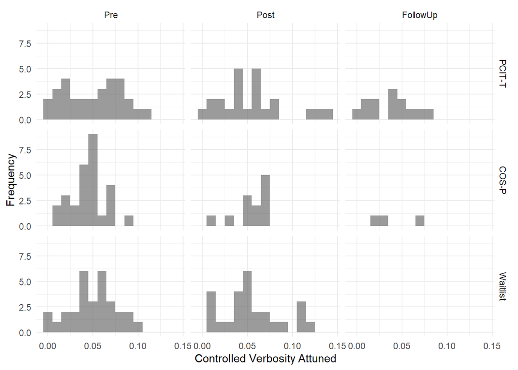

#### Model & Results

A linear mixed model with random effect for individual and fixed effects of group, time and the interaction was run. Estimated marginal means were obtained, and contrasts specified to test Hypothesis 1 and Hypothesis 2.

```
## fixed-effect model matrix is rank deficient so dropping 1 column / coefficient
```

```
## refitting model(s) with ML (instead of REML)
```

|  | Effect | npar | AIC | BIC | logLik | deviance | Chisq | Df | Pr(>Chisq) |
| --- | --- | --- | --- | --- | --- | --- | --- | --- | --- |
| result0 | Intercept | 3 | -720.932 | -711.614 | 363.466 | -726.932 | NA | NA | NA |
| result1 | Group | 5 | -717.479 | -701.949 | 363.739 | -727.479 | 0.547 | 2 | 0.761 |
| result2 | Time | 7 | -722.348 | -700.606 | 368.174 | -736.348 | 8.869 | 2 | 0.012 |
| result3 | Group*Time | 10 | -717.351 | -686.291 | 368.675 | -737.351 | 1.003 | 3 | 0.800 |

This is the ANOVA table for the model. p-values are likelihood ratio tests for adding the new term to the model just before. A p-value <0.05 indicates that adding that term results in better model fit. The most important p-value is the interaction p-value. Here, there is no evidence that the pattern of change over time is different among the groups (p=0.8).

```r
summary(result3)
```

```
## Linear mixed model fit by REML. t-tests use Satterthwaite's method [
## lmerModLmerTest]
## Formula: outcome ~ group * time + (1 | id)
##    Data: dat
##
## REML criterion at convergence: -670.7
##
## Scaled residuals:
##      Min       1Q   Median       3Q      Max
## -1.62518 -0.53788 -0.02136  0.46047  3.12508
##
## Random effects:
##  Groups   Name        Variance  Std.Dev.
##  id       (Intercept) 0.0003826 0.01956
##  Residual             0.0004210 0.02052
## Number of obs: 165, groups:  id, 88
##
## Fixed effects:
##                Estimate Std. Error         df t value Pr(>|t|)
## (Intercept)    0.050060   0.005176 128.456587   9.672   <2e-16 ***
## group2        -0.005097   0.007449 128.456587  -0.684    0.495
## group3         0.000176   0.007320 128.456587   0.024    0.981
## time2          0.007296   0.005863  82.986071   1.244    0.217
## time3         -0.011737   0.007280  88.279330  -1.612    0.110
## group2:time2   0.004700   0.009698  92.248550   0.485    0.629
## group3:time2  -0.001971   0.008101  81.275607  -0.243    0.808
## group2:time3   0.012310   0.015871  96.306347   0.776    0.440
## ---
## Signif. codes:  0 '***' 0.001 '**' 0.01 '*' 0.05 '.' 0.1 ' ' 1
##
## Correlation of Fixed Effects:
##             (Intr) group2 group3 time2  time3  grp2:2 grp3:2
## group2      -0.695
## group3      -0.707  0.491
## time2       -0.462  0.321  0.327
## time3       -0.372  0.259  0.263  0.376
## group2:tim2  0.280 -0.402 -0.198 -0.605 -0.228
## group3:tim2  0.335 -0.233 -0.473 -0.724 -0.272  0.438
## group2:tim3  0.171 -0.246 -0.121 -0.173 -0.459  0.264  0.125
## fit warnings:
## fixed-effect model matrix is rank deficient so dropping 1 column / coefficient
```

#### Estimated Means & Change

Estimated means for each Treatment and Time are presented. In addition, within-group change between time points is presented with 95% CIs.

##### Group mean difference at each timepoint

Effect sizes all calculated by the pooled T1 SD of the outcome. Adjusted p-value from Bonferroni correction.

Group Differences at Each Time Point

| Group Difference | Time | Mean | SE | t | p | adj p | Lower CL | Upper CL | Effect Size | Lower CL | Upper CL |
| --- | --- | --- | --- | --- | --- | --- | --- | --- | --- | --- | --- |
| 1 - 2 | 1 | 0.005 | 0.007 | 0.684 | 0.773 | 1 | -0.013 | 0.023 | 0.196 | -0.385 | 0.695 |
| 1 - 3 | 1 | 0.000 | 0.007 | -0.024 | 1.000 | 1 | -0.018 | 0.017 | -0.007 | -0.477 | 0.519 |
| 2 - 3 | 1 | -0.005 | 0.007 | -0.708 | 0.759 | 1 | -0.023 | 0.012 | -0.203 | -0.707 | 0.324 |
| 1 - 2 | 2 | 0.000 | 0.010 | 0.041 | 0.999 | 1 | -0.022 | 0.023 | 0.015 | -0.640 | 0.630 |
| 1 - 3 | 2 | 0.002 | 0.008 | 0.226 | 0.972 | 1 | -0.017 | 0.021 | 0.069 | -0.465 | 0.611 |
| 2 - 3 | 2 | 0.001 | 0.009 | 0.148 | 0.988 | 1 | -0.021 | 0.024 | 0.054 | -0.600 | 0.718 |
| 1 - 2 | 3 | -0.007 | 0.016 | -0.454 | 0.893 | 1 | -0.045 | 0.030 | -0.277 | -1.446 | 0.803 |
| 1 - 3 | 3 | NA | NA | NA | NA | NA | NA | NA | NA | NA | NA |
| 2 - 3 | 3 | NA | NA | NA | NA | NA | NA | NA | NA | NA | NA |

* Effect size scaled by pooled T1 SD  
† ES 95% Bootstrapped Percentile CI limits  
‡ If you want a positive ES (and it is calculated as negative), be sure to switch the signs and positions of the lower and upper CIs.

##### Change within each group

Within-Group Change and Effect Sizes

| Change | Group | Mean | SE | t | p | adj p | Lower CL | Upper CL | Effect Size | Lower CL | Upper CL |
| --- | --- | --- | --- | --- | --- | --- | --- | --- | --- | --- | --- |
| 1 - 2 | 1 | -0.007 | 0.006 | -1.242 | 0.432 | 0.653 | -0.021 | 0.007 | -0.280 | -0.711 | 0.146 |
| 1 - 3 | 1 | 0.012 | 0.007 | 1.606 | 0.249 | 0.336 | -0.006 | 0.029 | 0.451 | -0.107 | 0.970 |
| 2 - 3 | 1 | 0.019 | 0.007 | 2.555 | 0.033 | 0.037 | 0.001 | 0.037 | 0.731 | 0.151 | 1.262 |
| 1 - 2 | 2 | -0.012 | 0.008 | -1.545 | 0.275 | 0.377 | -0.030 | 0.006 | -0.461 | -0.970 | 0.128 |
| 1 - 3 | 2 | -0.001 | 0.014 | -0.040 | 0.999 | 1.000 | -0.034 | 0.033 | -0.022 | -1.086 | 0.900 |
| 2 - 3 | 2 | 0.011 | 0.015 | 0.786 | 0.713 | 1.000 | -0.023 | 0.046 | 0.439 | -0.570 | 1.425 |
| 1 - 2 | 3 | -0.005 | 0.006 | -0.951 | 0.610 | 1.000 | -0.019 | 0.008 | -0.205 | -0.561 | 0.168 |
| 1 - 3 | 3 | NA | NA | NA | NA | NA | NA | NA | NA | NA | NA |
| 2 - 3 | 3 | NA | NA | NA | NA | NA | NA | NA | NA | NA | NA |

* Effect size scaled by pooled T1 SD  
† ES 95% Bootstrapped Percentile CI limits  
‡ If you want a positive ES (and it is calculated as negative), be sure to switch the signs and positions of the lower and upper CIs.

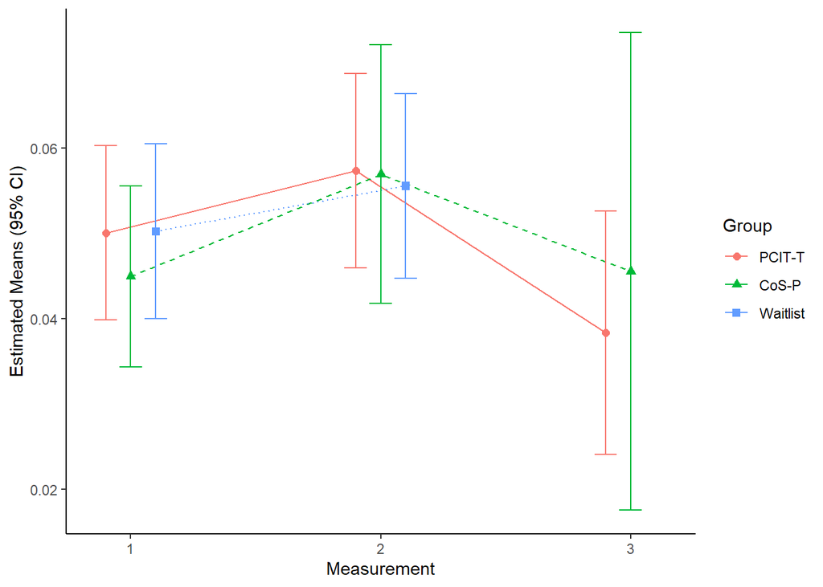

#### Hypothesis 1

We hypothesize that from baseline (‘T1’) to post-treatment/waitlist (‘T2’) there will be a gradient effect, whereby parent-child dyads who receive PCIT-T will show the greatest gains and parent-child dyads who receive no treatment will show the least gains. For the outcome, then, the null hypothesis is:

$H_0: \text {mean change}(\text{PCIT-T}) = \text {mean change}(\text{CoS-P}) = \text {mean change}(\text{Waitlist})$ $H_A: \text {mean change}(\text{PCIT-T}) > \text {mean change}(\text{CoS-P})$ $\&$ $\text {mean change}(\text{CoS-P}) > \text {mean change}(\text{Waitlist})$

For this, we test two tests, and then look at the magnitude of change within each group.

First, testing the two comparisons:

```
## group = 1:
##  contrast  estimate      SE   df t.ratio p.value
##  1 - 2    -0.007296 0.00587 81.8  -1.242  0.4321
##  1 - 3     0.011737 0.00731 87.1   1.606  0.2485
##  2 - 3     0.019033 0.00745 81.3   2.555  0.0331
##
## group = 2:
##  contrast  estimate      SE   df t.ratio p.value
##  1 - 2    -0.011996 0.00777 96.8  -1.545  0.2748
##  1 - 3    -0.000573 0.01420 97.4  -0.040  0.9991
##  2 - 3     0.011423 0.01454 89.1   0.786  0.7128
##
## group = 3:
##  contrast  estimate      SE   df t.ratio p.value
##  1 - 2    -0.005325 0.00560 78.2  -0.951  0.6096
##  1 - 3       nonEst      NA   NA      NA      NA
##  2 - 3       nonEst      NA   NA      NA      NA
##
## Degrees-of-freedom method: kenward-roger
## P value adjustment: tukey method for comparing a family of 3 estimates
```

| comp | t1t2change | did | cil | ciu | p | adjp |
| --- | --- | --- | --- | --- | --- | --- |
| G1 change vs G2 change | 0.007 | 0.005 | -0.014 | 0.024 | 0.628 | 0.968 |
| G2 change vs G3 change | 0.012 | -0.007 | -0.014 | 0.024 | 0.484 | 0.968 |

For test of difference between G1 and G2 in change from T1-2:  
p= 0.628. We have no evidence that there is a difference in the change over from Baseline to Post between the groups. The adjusted pvalue is 0.968.

p-values adjusted by Holm’s stepdown procedure.

| contrast | group | t1t2change | quality | p.value |
| --- | --- | --- | --- | --- |
| 1 - 2 | 1 | 0.007 | increase t1 to t2 | 0.432 |
| 1 - 2 | 2 | 0.012 | increase t1 to t2 | 0.275 |
| 1 - 2 | 3 | 0.005 | increase t1 to t2 | 0.610 |

Is the ordering of change satisfied?

Assuming an increase is better (positive change is improvement)

Greatest to least change from t1 to t2: Order not satisfied

Assuming an decrease is better (negative change is improvement)

Greatest to least change from t1 to t2: Order not satisfied

#### Hypothesis 2

There will be a gradient of size of change from T2 to T3 such that the change in the PCIT-T group > the change in the CoS-P group. This isn’t really a gradient; it’s just 1 hypothesis.

First, the change in PCITT and COSP from time 2 to time 3:

| contrast | group | t2t3change | quality | p.value |
| --- | --- | --- | --- | --- |
| 2 - 3 | 1 | -0.019 | decreased t2 to t3 | 0.033 |
| 2 - 3 | 2 | -0.011 | decreased t2 to t3 | 0.713 |
| 2 - 3 | 3 | NA | NA | NA |

```
##
##   Simultaneous Tests for General Linear Hypotheses
##
## Fit: lmer(formula = outcome ~ group * time + (1 | id), data = dat)
##
## Linear Hypotheses:
##        Estimate Std. Error z value Pr(>|z|)
## 1 == 0  0.00761    0.01627   0.468     0.64
## (Adjusted p values reported -- single-step method)
```

```
##
##   Simultaneous Confidence Intervals
##
## Fit: lmer(formula = outcome ~ group * time + (1 | id), data = dat)
##
## Quantile = 1.96
## 95% family-wise confidence level
##
##
## Linear Hypotheses:
##        Estimate lwr      upr
## 1 == 0  0.00761 -0.02427  0.03949
```

p=0.64, so we have no evidence to suggest that the change from t2 to t3 in PCITT is different than the change in COSP.

Assuming an increase in scores is better, PCITT < COS-P, increase was not greater in PCITT

Assuming a decrease in scores is better,PCITT > COS-P, decrease was greater in PCITT

#### Residuals

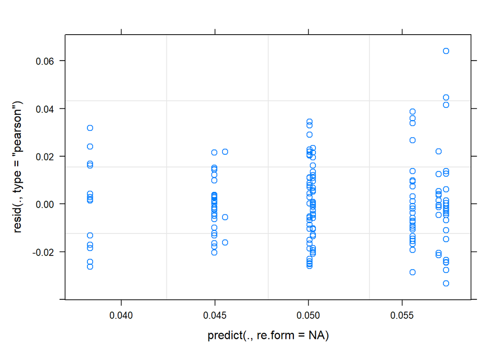

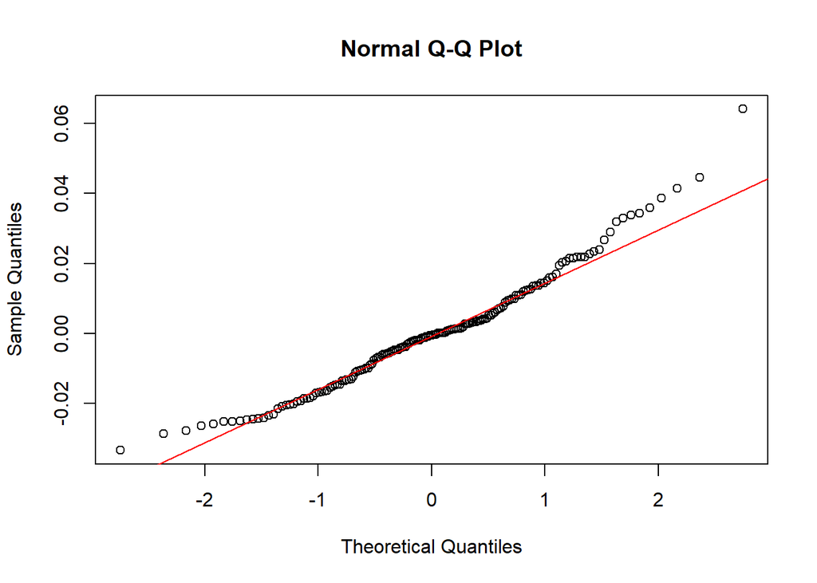

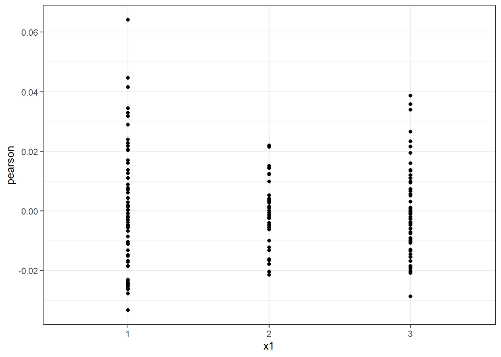

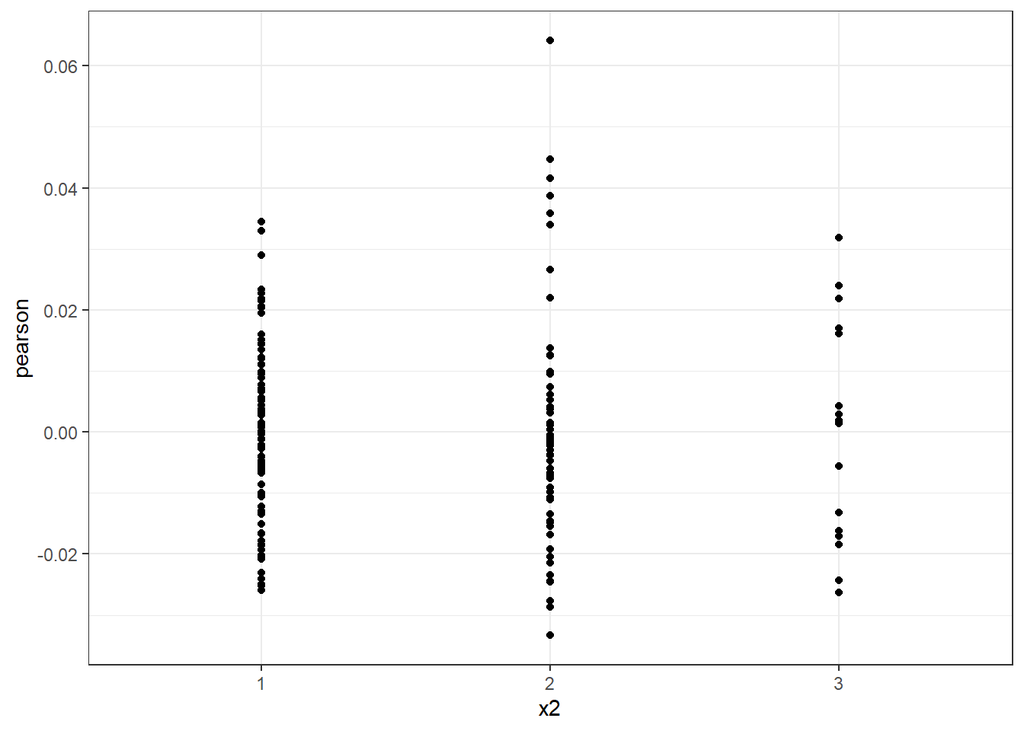

```r
rm(list = ls())
```